Проведём импорт нужный библиотек

```python
import os
import numpy as np
import matplotlib.pyplot as plt

if not os.path.exists('thinkdsp.py'):
    !wget https://github.com/AllenDowney/ThinkDSP/raw/master/code/thinkdsp.py
from thinkdsp import decorate, SinSignal, Chirp, normalize, unbias, read_wave
```

[output not shown]

# **Упражнение 3.1**

Запустите и прослушайте примеры из блокнота `chap03.ipynb`.

В примере с утечкой замените окно Хэмминга одним из окон, предоставляемых NumPy, и посмотрите, как они влияют на утечку.

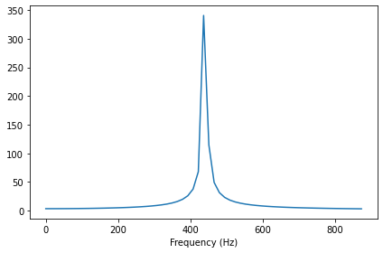

```python
sin_signal = SinSignal()
sin_signal_duration = sin_signal.period * 30.25
sin_signal_wave = sin_signal.make_wave(sin_signal_duration)
sin_signal_spectrum = sin_signal_wave.make_spectrum()
sin_signal_spectrum.plot(high=880)
decorate(xlabel='Frequency (Hz)')
```

Сравним 4 окна, предоставляемых NumPy:

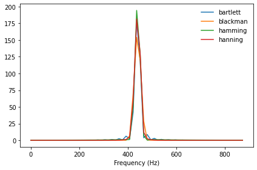

```python
for window_func in [np.bartlett, np.blackman, np.hamming, np.hanning]:
    wave = sin_signal.make_wave(sin_signal_duration)
    wave.ys *= window_func(len(wave.ys))

    spectrum = wave.make_spectrum()
    spectrum.plot(high=880, label=window_func.__name__)

decorate(xlabel='Frequency (Hz)')
```

Все 4 окна хорошо справляются с уменьшением утечек. Фильтр Бартлетта оставляет некоторый остаточный «звон». Фильтр Хэмминга рассеивает наименьшее количество энергии.

# **Упражнение 3.2**

Напишите класс, называемый `SawtoothChirp`, расширающий `Chirp` и переопределяющий `evaluate` для генерации пилообразного сигнала с линейно увеличивающейся (или уменьшающейся) частотой.

Подсказка: надо совместить функции evaluate из `Chirp` и `SawtoothSignal`.

Нарисуйте эскиз спектрограммы этого сигнала, а затем распечатайте ее. Эффект биений должен быть очевиден, а если сигнал внимательно прослушать, то биения можно и услышать.

Напишем необходимый класс:

```python
class SawtoothChirp(Chirp):
    def evaluate(self, ts):
        freqs = np.linspace(self.start, self.end, len(ts))
        dts = np.diff(ts, prepend=0)
        dphis = 2 * np.pi * freqs * dts
        phases = np.cumsum(dphis)
        cycles = phases / (2 * np.pi)
        frac, _ = np.modf(cycles)
        ys =  normalize(unbias(frac), self.amp)
        return ys
```

**ПРИ ПРОСЛУШИВАНИИ СОЗДАННЫХ МНОЙ ЗВУКОВ СДЕЛАЙТЕ ЗВУК ТИШЕ! БЕРЕГИТЕ УШИ И АУДИОУСТРОЙСТВА!**

Создадим сам сигнал:

```python
saw_tooth_chirp_signal = SawtoothChirp(start = 440, end = 880)
saw_tooth_chirp_wave = saw_tooth_chirp_signal.make_wave(duration=1, framerate=4000)
saw_tooth_chirp_wave.apodize()
saw_tooth_chirp_wave.make_audio()
```

[interactive chart not shown]

Слышно, как частота постепенно увеличивается.

Выполним кратковременное преобразование Фурье и выведем результат в виде спектограммы:

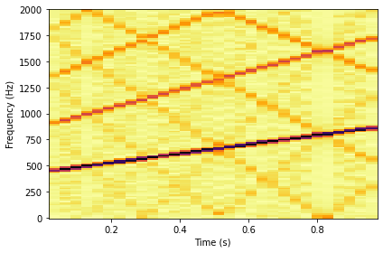

```python
saw_tooth_chirp_spect = saw_tooth_chirp_wave.make_spectrogram(256)
saw_tooth_chirp_spect.plot()
decorate(xlabel='Time (s)', ylabel='Frequency (Hz)')
```

Тёмно-коричневой линией обозначена наша основная частота, остальные частоты "отпрыгивают" от слышных на заднем плане.

# **Упражнение 3.3**

Создайте пилообразный чирп, меняющийся от 2500 до 3000 Гц, и на его основе сгенерируйте сигнал длительностью 1 сек. и с частотой 20 кГц. Нарисуйте, каким примерно будет `Spectrum`. Затем распечатайте `Spectrum` и посмотрите, правы ли вы.

Выполним заданные по заданию условия:

[interactive chart not shown]

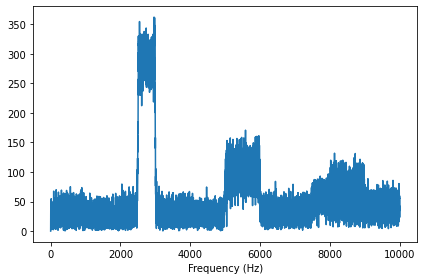

```python
saw_tooth_chirp_2500_3500_signal = SawtoothChirp(start=2500, end=3000)
saw_tooth_chirp_2500_3500_wave = saw_tooth_chirp_2500_3500_signal.make_wave(duration=1, framerate=20000)
saw_tooth_chirp_2500_3500_wave.make_spectrum().plot()
decorate(xlabel='Frequency (Hz)')
saw_tooth_chirp_2500_3500_wave.make_audio()
```

Видим (и слышим), что гармоники накладываются друг на друга. Видно что на частоте 2500 и 5000 Гц появляются возвышенности. Это происходит, так как в данном диапазоне равное изменение частоты занимает равное время.

# **Упражнение 3.4**

В музыкальной терминалогии *глиссандо* - это нота, меняющаяся от одной высоты до другой, то есть своеобразный чирп.

Найдите или запишите звук глиссандо и распечатайте спектрограмму первых нескольких секунд.

Так как запись звука в достаточном качестве не представляется возможной, возьмём звук из репозитория учебника (72475**rockwehrmann**glissup02.wav):

[output not shown]

[interactive chart not shown]

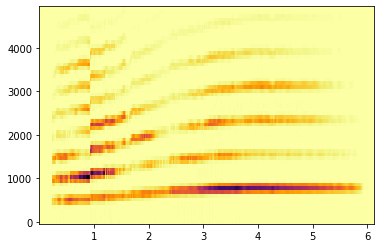

```python
if not os.path.exists('72475__rockwehrmann__glissup02.wav'):
    !wget https://github.com/AllenDowney/ThinkDSP/raw/master/code/72475__rockwehrmann__glissup02.wav

rockwehrmann__glissup02_wave = read_wave('72475__rockwehrmann__glissup02.wav')
rockwehrmann__glissup02_wave.make_spectrogram(512).plot(high=5000)
rockwehrmann__glissup02_wave.make_audio()
```

Видим, что спектограмма по общей форме похожа на наш чирп.

# **Упражнение 3.5**

Тромбонист играет глиссандо, непрерывно дуя в мундштук и двигая кулису тромбона.При этом общая длина трубы меняется, а играемая нота пропрорциональна этой длине.

Если предположить, что музыкант двигает кулису с постоянной скоростью, как будет меняться во времени частота?

Напишите класс, называемый `TromboneGliss`, расширяющий `Chirp` и предоставляющий `evaluate`. Создайте сигнал, имитирующий глиссандо на тромбоне от C3 до F3, и обратно до C3. C3 - 262 Гц; F3 - 349 Гц.

Напечатайте спектрограмму полученного сигнала. На что похоже глиссандо на тромбоне - на линейный или же экспоненциальный чирп?

Напишем необходимый класс:

```python
class TromboneGliss(Chirp):
    def evaluate(self, ts):
        l_start, l_end = 1.0 / self.start, 1.0 / self.end
        lengths = np.linspace(l_start, l_end, len(ts))
        freqs = 1 / lengths
        dts = np.diff(ts, prepend=0)
        dphis = np.pi * 2 * freqs * dts
        phases = np.cumsum(dphis)
        ys = self.amp * np.cos(phases)
        return ys
```

Создадим 2 сигнала, после чего соединим их. Первый сигнал и его спектрограмма:

[interactive chart not shown]

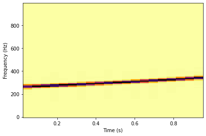

```python
low_C3 = 262
high_F3 = 349
trombone_gliss_signal_low_to_high = TromboneGliss(low_C3, high_F3)
trombone_gliss_wave1 = trombone_gliss_signal_low_to_high.make_wave(duration=1)
trombone_gliss_wave1.apodize()
trombone_gliss_spect = trombone_gliss_wave1.make_spectrogram(1024)
trombone_gliss_spect.plot(high=1000)
decorate(xlabel='Time (s)', ylabel='Frequency (Hz)')
trombone_gliss_wave1.make_audio()
```

2-й сигнал и его спектрограмма:

[interactive chart not shown]

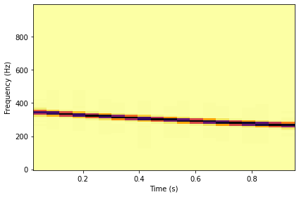

```python
trombone_gliss_signal_high_to_low = TromboneGliss(high_F3, low_C3)
trombone_gliss_wave2 = trombone_gliss_signal_high_to_low.make_wave(duration=1)
trombone_gliss_wave2.apodize()
trombone_gliss_spect = trombone_gliss_wave2.make_spectrogram(1024)
trombone_gliss_spect.plot(high=1000)
decorate(xlabel='Time (s)', ylabel='Frequency (Hz)')
trombone_gliss_wave2.make_audio()
```

Соединим 2 сигнала и посмотрим на их спектограмму:

[interactive chart not shown]

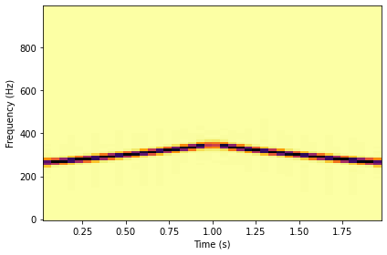

```python
trombone_gliss_wave_result = trombone_gliss_wave1 | trombone_gliss_wave2
trombone_gliss_spect_result = trombone_gliss_wave_result.make_spectrogram(1024)
trombone_gliss_spect_result.plot(high=1000)
decorate(xlabel='Time (s)', ylabel='Frequency (Hz)')
trombone_gliss_wave_result.make_audio()
```

Получили требуемый звук.

# **Упражнение 3.6**

Сделайте или найдите запись серии гласных звуков и посмотрите на спектрограмму. Сможете ли вы различить разные глассные?

Так как запись звуков гласных в достаточном качестве не представляется возможной, возьмём гласные из репозитория учебника (87778**marcgascon7**vocals.wav):

```python
if not os.path.exists('87778__marcgascon7__vocals.wav'):
    !wget https://github.com/AllenDowney/ThinkDSP/raw/master/code/87778__marcgascon7__vocals.wav

vowels_wave = read_wave('87778__marcgascon7__vocals.wav')
vowels_wave.make_audio()
```

[output not shown]

[interactive chart not shown]

Построим спектрограмму звука этих глассных:

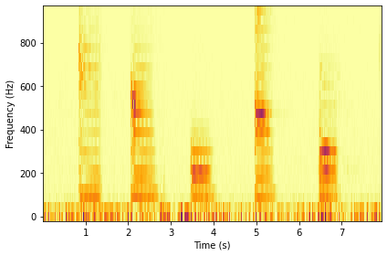

```python
vowels_wave.make_spectrogram(1024).plot(high=1000)
decorate(xlabel='Time (s)', ylabel='Frequency (Hz)')
```

На спектрограмме четко видны пики. Это и есть наши глассные.